# data

KIM MINJI

2020 12 12

1. 서울, 경기, 강원 지역의 국립공원 위치를 지도 상에 마커로 표시하되 국립공원의 이름을 함께 표시하시오. (국립공원 관리공단 홈페이지: http://www.knps.or.kr/portal/main.do)

```r
install.packages("ggmap", repos = "http://cran.us.r-project.org")
```

```r
install.packages("ggplot2", repos = "http://cran.us.r-project.org")
library(ggmap)
register_google(key = 'AIzaSyBpRT01Ya703cY6KU8E6OwpMR2L1H7LUMo')

names <- c("북한산 국립공원","설악산 국립공원","오대산 국립공원","치악산 국립공원","태백산 국립공원")
addr <- c("경기 고양시 덕양구 대서문길 375",
          "강원 인제군 북면 한계리",
          "강원 홍천군 내면 오대산로 2",
          "강원 원주시 소초면 무쇠점2길 26",
          "강원 태백시 혈동")
gc <- geocode(enc2utf8(addr))
gc
```

```
## # A tibble: 5 x 2
##     lon   lat
##   <dbl> <dbl>
## 1  127.  37.6
## 2  128.  38.1
## 3  129.  37.7
## 4  128.  37.4
## 5  129.  37.1
```

```r
df <- data.frame(name=names,
                 lon=gc$lon,
                 lat=gc$lat)
df
```

```
##              name      lon      lat
## 1 북한산 국립공원 126.9748 37.64513
## 2 설악산 국립공원 128.3023 38.12275
## 3 오대산 국립공원 128.6021 37.70270
## 4 치악산 국립공원 128.0504 37.41402
## 5 태백산 국립공원 128.9117 37.12512
```

[figure not shown]

```r
cen <- c(mean(df$lon),mean(df$lat))
map <- get_googlemap(center = cen,
                     maptype = "roadmap",
                     zoom=7,
                     size=c(640,640),
                     markers=gc)
ggmap(map)
```

[figure not shown]

```r
gmap <- ggmap(map)
gmap+geom_text(data=df,
               aes(x=lon, y=lat),
               size=3,
               label=df$name)
```

2. treemap 패키지의 GNI2014 데이터셋을 이용하여 북아메리카(North America) 대륙에 있는 각 나라의 위치에 그 나라의 인구수를 원의 크기로 표시하시오. (원의 색은 초록색, alpha=0.5)

```r
install.packages("treemap", repos = "http://cran.us.r-project.org")
library(treemap)

data("GNI2014")
head(GNI2014)
```

```
##   iso3          country     continent population    GNI
## 3  BMU          Bermuda North America      67837 106140
## 4  NOR           Norway        Europe    4676305 103630
## 5  QAT            Qatar          Asia     833285  92200
## 6  CHE      Switzerland        Europe    7604467  88120
## 7  MAC Macao SAR, China          Asia     559846  76270
## 8  LUX       Luxembourg        Europe     491775  75990
```

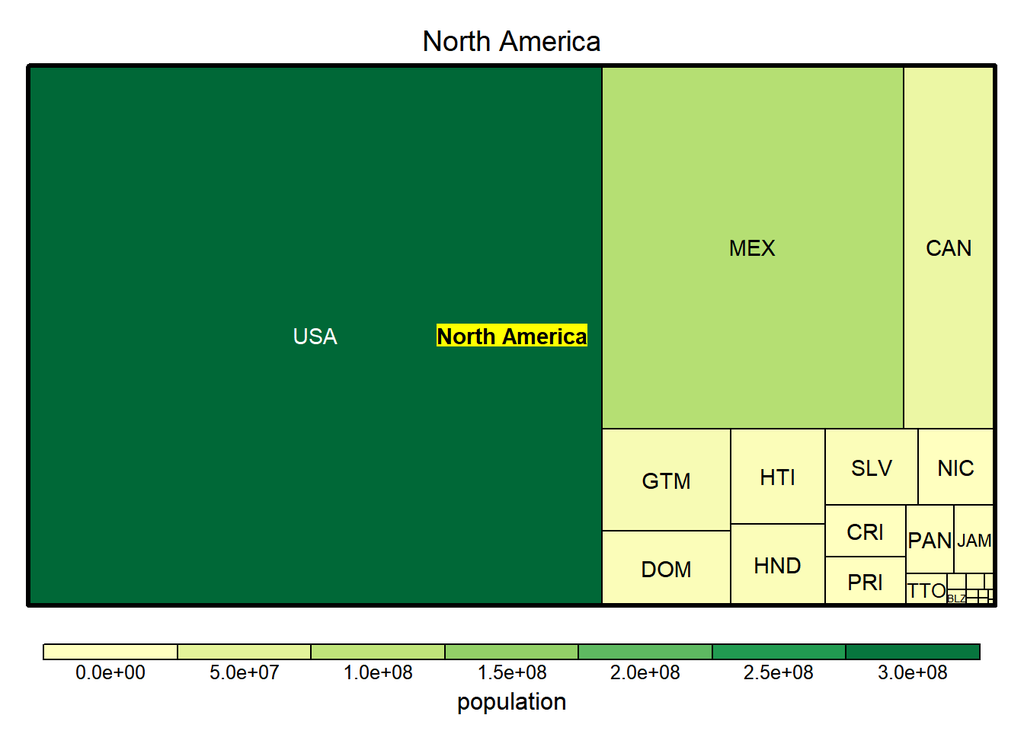

```r
city <- GNI2014[GNI2014$continent == 'North America', ]

treemap(city,
        index = c("continent","iso3"),
        vSize = "population",
        vColor = "population",
        type = "value",
        bg.labels = "yellow",
        title = "North America")
```

```r
install.packages("MASS", repos = "http://cran.us.r-project.org")
```

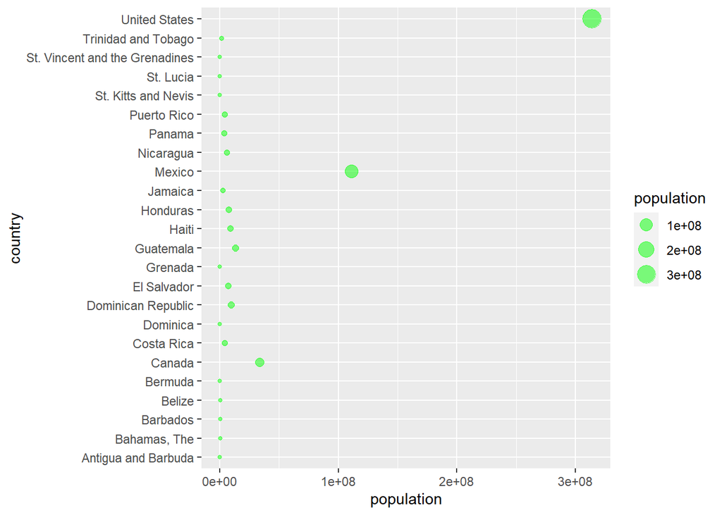

```r
library(MASS)

ggplot(city, aes(x=population, y=country)) +
  geom_point(aes(size=population), shape=21, colour="green", fill="green", alpha=0.5)
```

3. 스티브 잡스의 스탠포드 대학 졸업식 연설문에 대해 워드클라우드를 작성하시오. (steve Jobs.txt)

```r
library(KoNLP)
```

```r
library(wordcloud)
library(RColorBrewer)

txt <- readLines("steve Jobs.txt", encoding = "UTF-8")
buildDictionary(ext_dic = "woorimalsam")
```

```
## 629897 words dictionary was built.
```

```r
pal2 <- brewer.pal(8, "Dark2")
noun <- sapply(txt,extractNoun,USE.NAMES=F)
noun
```

```
## [[1]]
##  [1] "오늘"   "세계"   "최고"   "대학"   "중"     "한"     "곳"     "졸업"
##  [9] "식"     "참석"   "영광"   "나"     "대학"   "졸업"   "한"     "적"
## [17] "오늘"   "대학"   "졸업"   "식"     "근접"   "것"     "오늘"   "저"
## [25] "내"     "인생"   "세"     "가지"   "이야기" "대단"   "한"     "얘기"
## [33] "세"     "가지"
##
## [[2]]
## [1] ""
##
## [[3]]
## [1] "첫"     "번째"   "얘기"   "점"     "관련"   "이야기"
##
## [[4]]
## [1] ""
##
## [[5]]
##  [1] "저"           "리드"         "대학"         "6"            "개월"
##  [6] "자퇴했습니다" "나"           "18"           "개월"         "동안"
## [11] "도강"         "나"           "진짜"         "나"           "자퇴"
##
## [[6]]
## [1] ""
##
## [[7]]
##  [1] "이"               "저"               "전"               "이야기"
##  [5] "Unwed"            "대학생"           "나"               "친어머니"
##  [9] "저"               "입양"             "결심"             "거"
## [13] "그녀"             "나"               "대학"             "졸업생"
## [17] "들"               "입양"             "되"               "생각"
## [21] "것"               "나"               "변호"             "사"
## [25] "부인"             "입양"             "되"               "짜"
## [29] "나"               "시작"             "때"               "그"
## [33] "그"               "정말"             "여자"             "아이"
## [37] "결심"             "것"               "제외"             "나"
## [41] "부모님"           "들"               "자정"             "도움"
## [45] "전화"             "“"               "우리"             "남자"
## [49] "아이"             "”"               "당신"             "아이"
## [53] "그"               "“물론이지”라고" "말"               "나"
## [57] "친어머니"         "후"               "나"               "어머니"
```

[output cut: 323 more lines]

```
##  [1] "그것"    "저자"    "들"      "마지막"  "메시지"  "것"      "Stay"
##  [8] "Hungry"  "Stay"    "Foolish" "나"      "내"      "자신"    "소원"
## [15] "출발"    "졸업"    "하"      "여러"    "분"      "들"      "말씀"
##
## [[60]]
## [1] ""
##
## [[61]]
## [1] "Stay"    "Hungry"  "Stay"    "Foolish"
##
## [[62]]
## [1] ""
##
## [[63]]
## [1] "감사"
```

```r
noun2 <- unlist(noun)
wordcount <- table(noun2)

temp <- sort(wordcount, decreasing = T)[1 : 10]
temp
```

```
## noun2
##   나   것        한   일   내 대학   때   수   들
##   76   49   31   30   21   17   16   14   14   13
```

```r
temp <- temp[-1]
temp
```

```
## noun2
##   것        한   일   내 대학   때   수   들
##   49   31   30   21   17   16   14   14   13
```

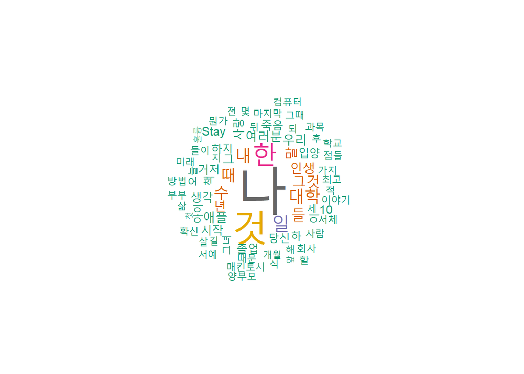

```r
wordcloud(names(wordcount),
          freq = wordcount,
          scale = c(5, 0.7),
          min.freq = 4,
        random.order = F,
        rot.per = .1,
        colors = pal2)
```

```r
df <- read.csv("datalab.csv")
df
```

```
##            url
## 1         주제
## 2         범위
## 3         기간
## 4         성별
## 5       연령대
## 6         날짜
## 7   2019-12-12
## 8   2019-12-13
## 9   2019-12-14
## 10  2019-12-15
## 11  2019-12-16
## 12  2019-12-17
## 13  2019-12-18
## 14  2019-12-19
```

[output cut: 1107 more lines]

5. 완성된 파일을 본인의 깃허브에 커밋하여 업로드하시오. (깃허브 주소 제출)